# Temperature sensitivity

Ross Nygard e.nygard@ufl.edu

2022-11-19 18:47:38

# Objectives

The objectives in this assignment are:

- Create functions in R to simulate responses to a driving variable.
- Construct a simulation to investigate a question.
- Analyze the results of a simulation including it’s assumptions and limitations.

# Background

Soil carbon stocks are primarily the result of inputs from dead plants (organic material) and losses as decomposing microbes eat that material and respire it as carbon dioxide. How quickly the microbes metabolized organic material is the result of a number of factors including temperature (warmer microbes metabolize faster), moisture (too much water and the microbes drown, not enough and they dry out), and other soil properties that change the micro-habitat of the soil. Temperature is the most widely agreed upon driver of soil carbon decay rates and what we will focus on for this assignment. In general, the amount of carbon that leaves the soil is proportional to the amount of carbon that is there and the decay rate doubles with 10 $^\circ$C of warming.

$$\frac{dC}{dt} =
-kCQ_{10}^{(T-T_0)/10}$$

where $C$ is the soil carbon stock, $t$ is the time, $k$ is the decay rate (assumed to be 1/15 [per year]), $Q_{10}$ the relative change in decay rates with 10$^\circ$C of warming (assumed to be 2 [unit-less]), $T$ the temperature, and $T_0$ a reference temperature (assumed to be 15 [$\circ$C]).

Often the temperature used is an annual average but, as you know, temperature varies on daily and annual cycles and is currently undergoing annual increases. In this assignment you will construct three function to simulation temperature at the sub-daily, annual, and decade timescales using cyclic `sin` or `cos` functions. Then link them together to create functions that include different time scales and how these time resolutions affect projected soil carbon changes.

# Sub-daily, daily and annual temperture

Create a function for the hourly temperature that has the maximum temperature occurring at 4PM, minimum at 4AM, a range of 10$^\circ$C and a daily average of 15$^\circ$ Use this function to make a plot of two days with the hour on the x-axis and the temperature on the y-axis.

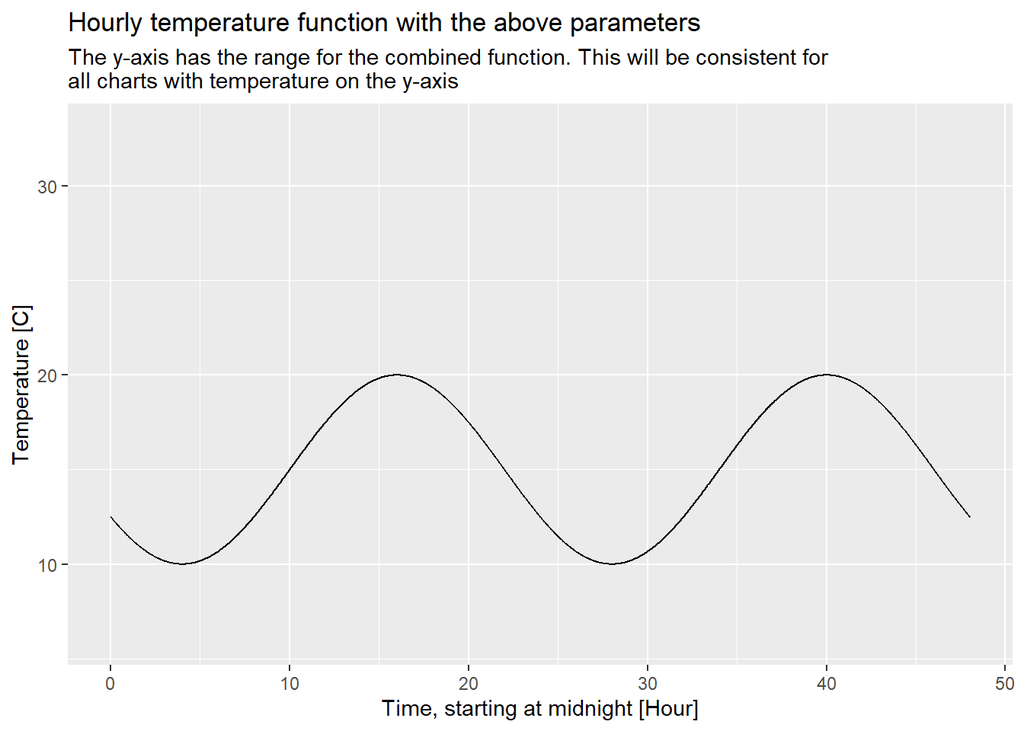

Create a second function for the annual mean-daily temperature with the minimum temperature in January (beginning of the year), maximum temperature in June (half way through the year), a annual temperature range of 15$^\circ$C and a mean temperature of 20$^\circ$C. Use this function to make a plot for two years with the year on the x-axis and the temperature on the y-axis.

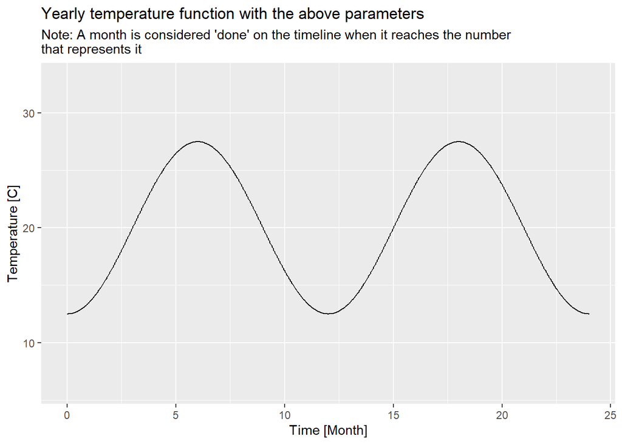

Create a third function that has a linear increase in temperature at a rate of 0.008 $^\circ$C per year and an initial temperature of 20$^\circ$C. Make a plot showing the temperature over 30 years.

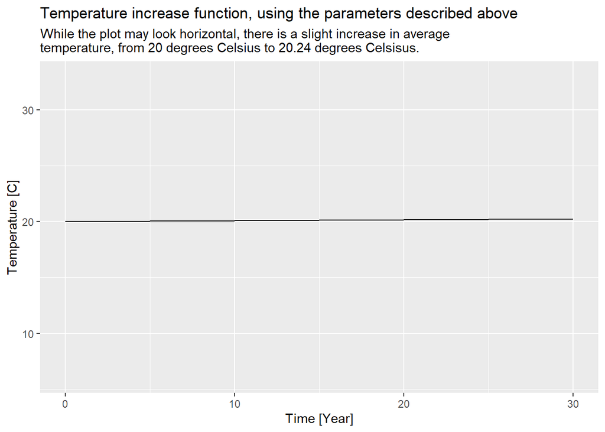

Combine the three functions to create a single function that accounts for both the diurnal and annual temperature fluctuations as well as the decadal increases in temperature. Use this function to make a series of plots that show temperature variations on the timescales listed above.

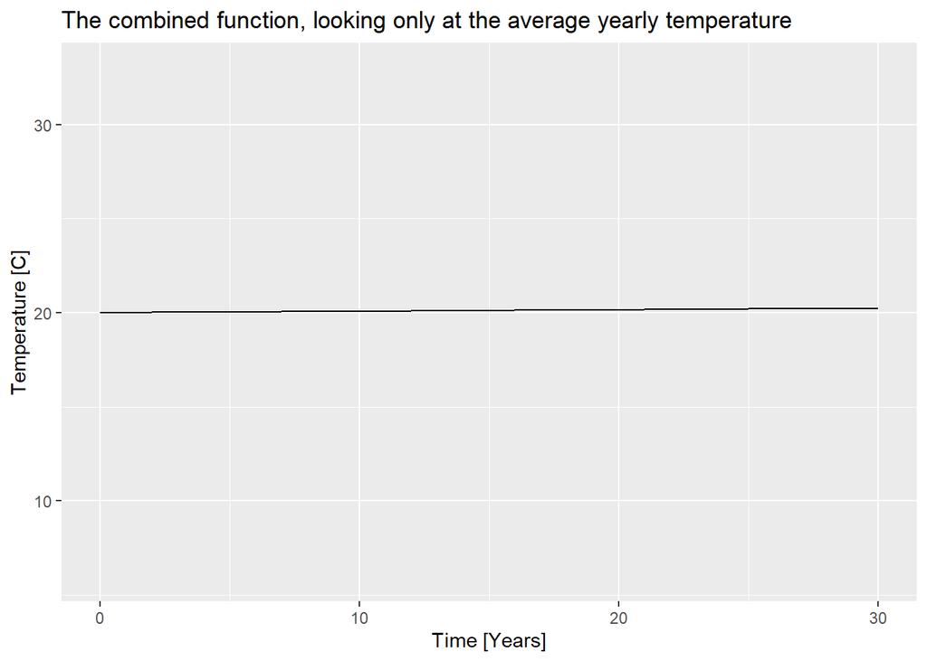

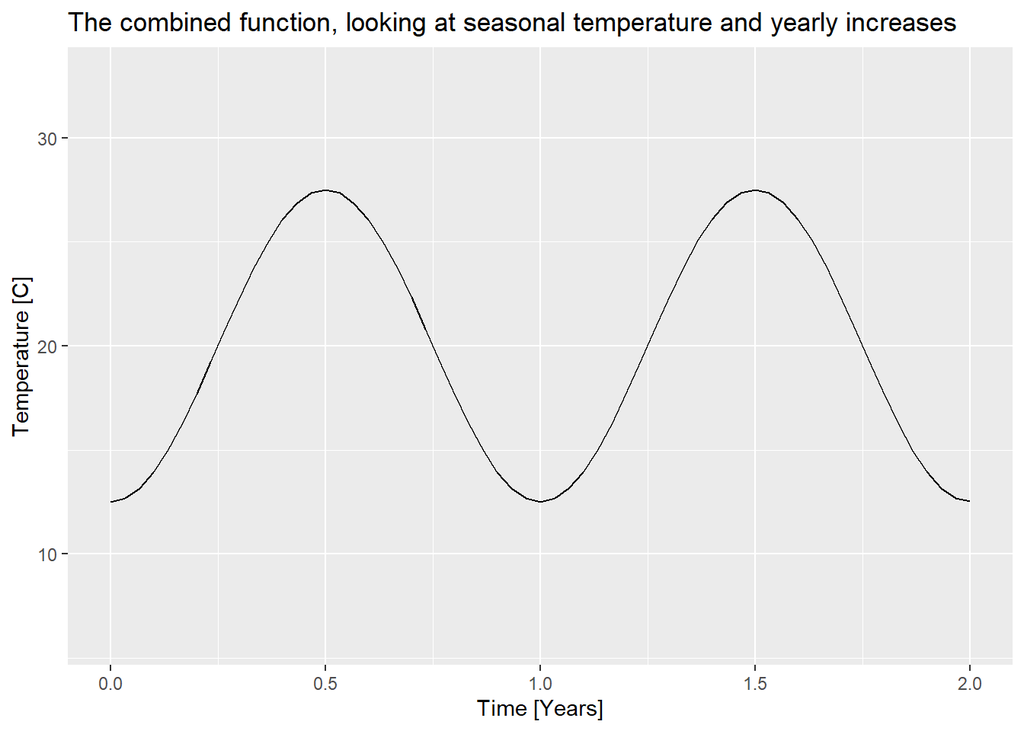

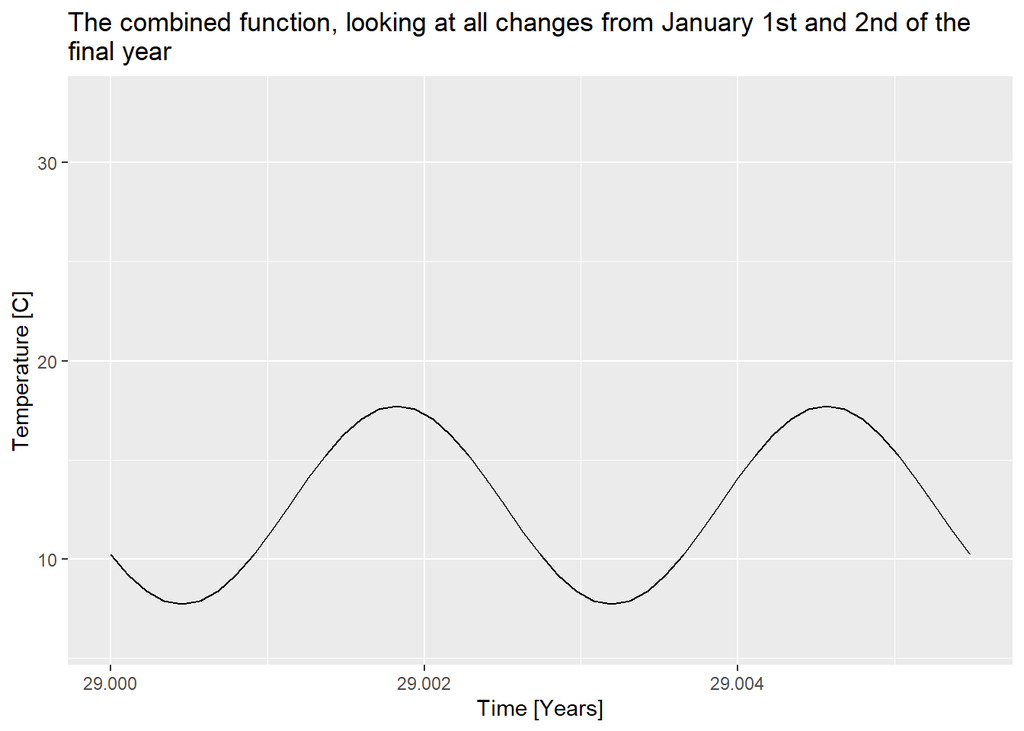

# Cumulative carbon loss

Create four functions for the rate of change of the soil carbon stocks that consider the following temperature cycles at a 30 year time horizon:

1. a static reference
2. increases in mean annual temperature
3. increases in mean annual temperature and sub-annual seasonal changes
4. increases in mean annual temperature, sub-annual seasonal changes, and daily temperature cycles.

Solve the differential equation using `deSolve::lsoda` and plot the results. Assume that you start with 10 kg-C m$^2$. Defend the time step that you choose to use, remember to balance memory load and precision. Compare the results of each with the most detailed simulation in a figure.

> The static temperature has a time step of one year. Because temperature does not change over time, it doesn’t need a more detailed time step. It is calculated with a timestep of 1/2190 for the sake of plotting it together with the hourly temperature resolution.

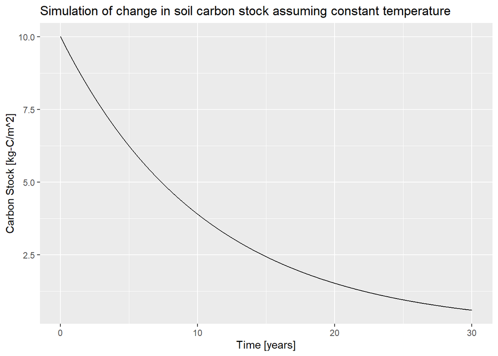

> The annual temperature increases also use a time step of one year. The temperature does not change much over the course of a year, only 0.008 degrees Celsius. Over the course of the model, it would not increase by 1 degree Celsius. It is calculation with a timestep of 1/2190 for the sake of plotting it together with the hourly temperature resolution.

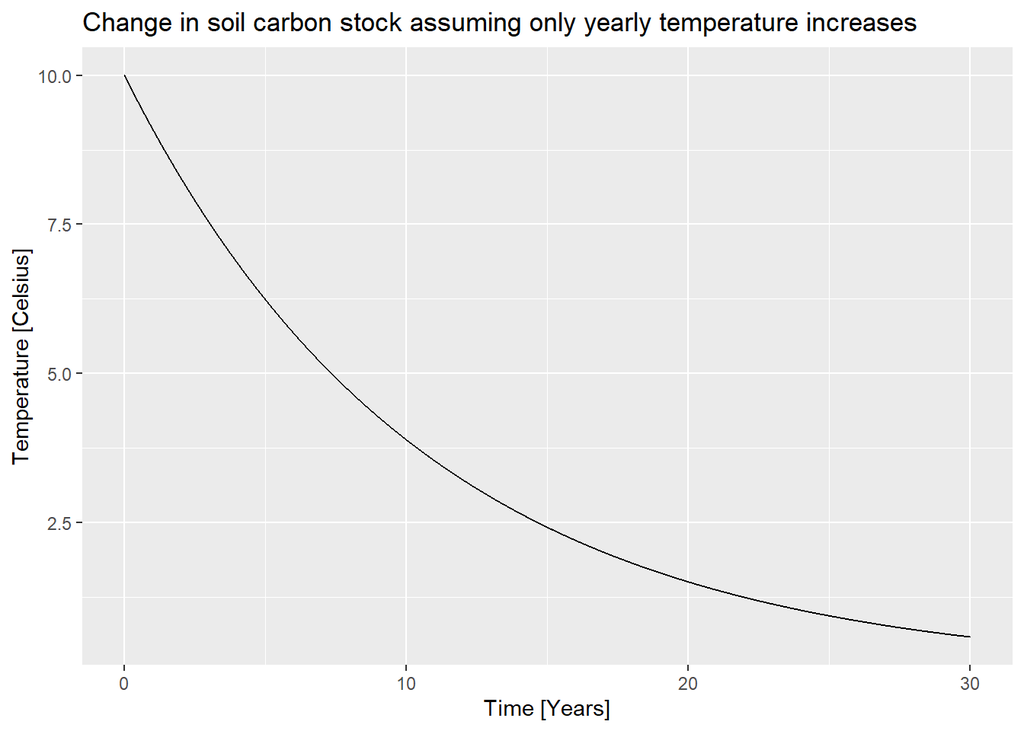

> The simulation with seasonal temperature changes can use a time step of 1/6, or roughly 2 months. This catches some of the precision of the seasonal changes without taking up large amounts of memory, especially as the hourly temperature changes will need an even greater degree of precision. It is calculated with a timestep of 1/2190 for the sake of plotting it together with the hourly temperature resolution.

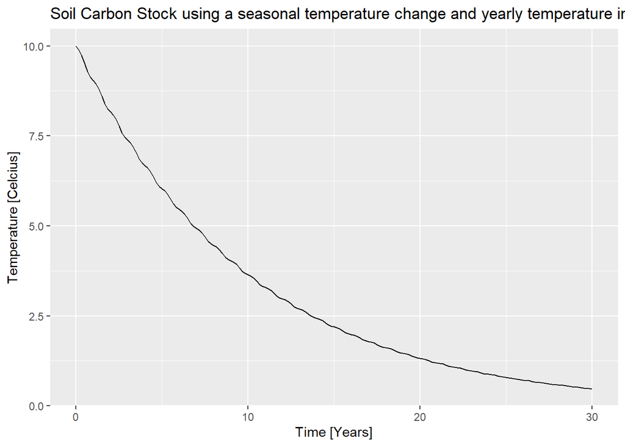

> The simulation with hourly temperature changes used a time step of 1/2190 to start with, or roughly 4 hours. This is to catch some of the precision while attempting to take up less memory.

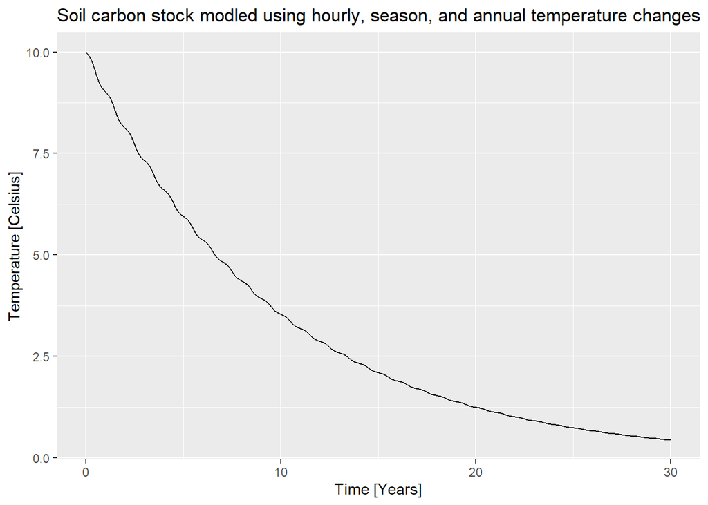

> All simulations are plotted together below.

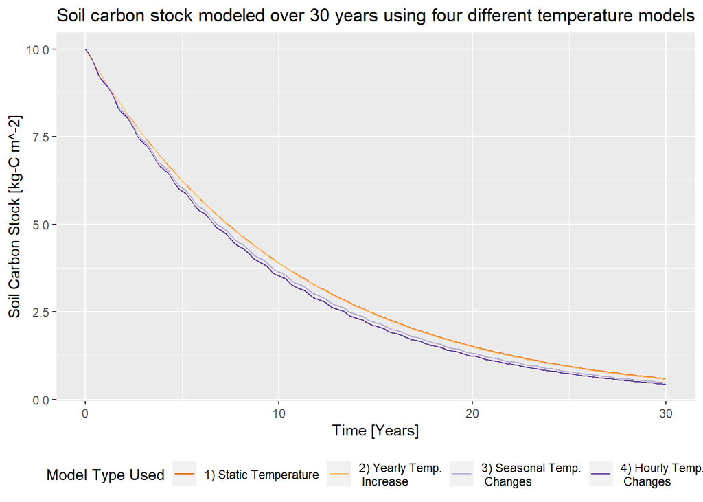

# Modeling report

> A client in the carbon credit market space has asked for a rough estimate of how much error they would introduce into a soil decay model by only considering annual rather then hourly temperature variation for a 30 year time horizen. Write a *brief* well-formatted report answering this question (<3 figures and <500 narrative words), include a systems diagram and the mathematical form of the model. Assume that your client does not care about your code and mute the code chunks in this section of the report, but that some poor intern will be asked to extend this work so make sure the code is well commented. You may use the functions you define above without repeating them again. You may borrow from the background given above but should use your own words and cite your sources (drawn from here or elsewhere).

> Your report should address the following: Why should the reader care? A short description of the model. What results does the model show? What are key limintations and assumptions? How could you provide a better answer, if only they gave you more time and money.

## Introduction

Carbon dioxide can reenter the atmosphere after living tissue is decomposed in the soil. The decay rates of the carbon-containing tissues in the soil are dependent on several factors, but the one with most influence is temperature. Temperature can vary several degrees over the course of several years, each season, and a single day. These different variations are important to examine to understand how much carbon may be leaving the soil, especially after a prolonged period.

## Model description

The different models for temperature are:

1: a static temperature $(T_{\text{static}}=20^\circ C)$,

2: a yearly average temperature with warming considered $\big(T_{\text{yearly average}}=20^\circ C + (0.008 \frac{^\circ C}{year}*t\big)$,

3: a seasonal temperature variation with yearly warming $\big(T_{\text{seasonal variation}}=-\frac{15^\circ C}{2} * \cos(2πt)+T_{\text{yearly averag}e} \big)$,

and 4: an hourly temperature variation with both seasonal and yearly warming considered $\big(T_{ \text{hourly variation}}=-5^\circ C * \sin \big(730 π t + \frac{π}{6} \big) + T_{ \text{seasonal variation}} \big)$.

The amount of carbon leaving the soil is proportional to the existing caron in the soil, and it doubles with 10°C of warming. The rate of decay is

$\frac{dC}{dt}=-kCQ_{10}^{(T-T_0)/10}$

where $C$ is the carbon in the soil in $\frac{kg-C}{m^2}$, $t$ is time in years, $k$ is the decay rate, $Q_{10}$ is change in relative decay rate with 10°C of warming, and $T$ is a temperature. The values of everything in this equation will be constants excluding $C$, $t$, and $T$. $t$ will vary from 0 years to 30 years, $T$ is determined by the temperature model used and $t$, and $C$ is dependent on both $T$ and $t$. The default values for the rest are $k=\frac{1}{15 year}$, $Q_{10}=2$ (unitless), and $T_0=15^\circ C$. The initial value is $C=10 \frac{(kg-C)}{m^2}$.

## Results

The results of running the four different models with $t$ increasing in increments of 4 hours are shown below.

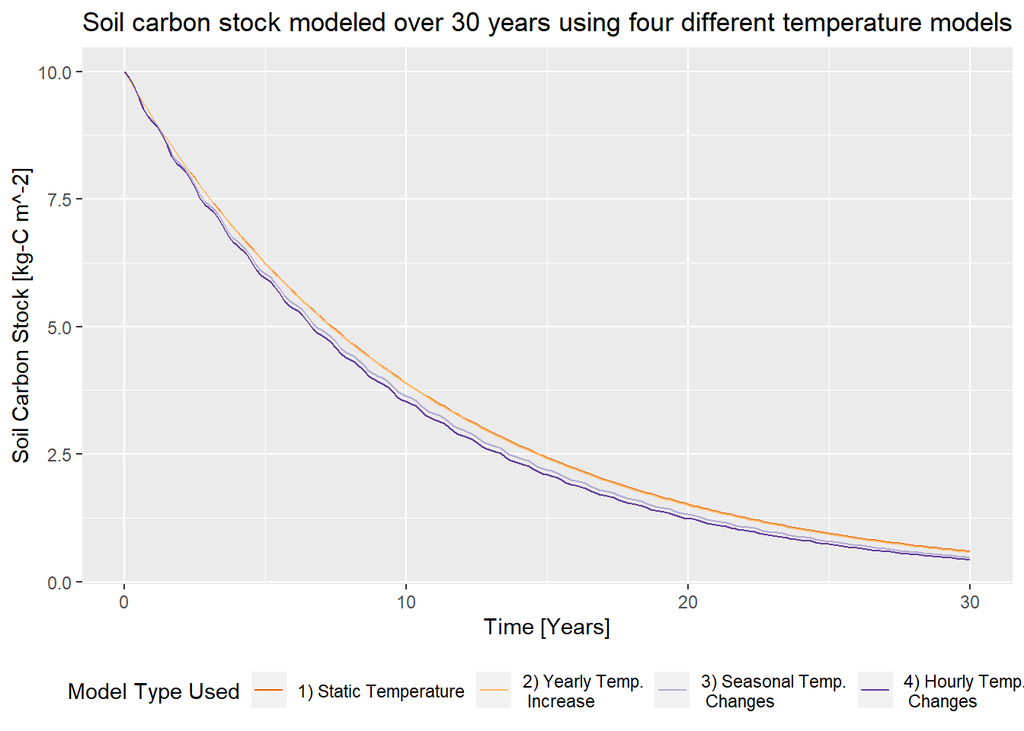

Figure 1: The static temperature model and the yearly temperature increase model have similar enough changes in carbon stock over 30 years that they do not show as different in the graph. Seasonal variations show fluctuations in the amount of decay on account of seasonal temperature changes, but hourly temperature changes are noticeably lower than seasonal variation without hourly.

Plotting the end values of C for each simulation in a bar chart allows a better view of how much carbon is missed if the yearly temperature simulation is used as opposed to the hourly temperature simulation.

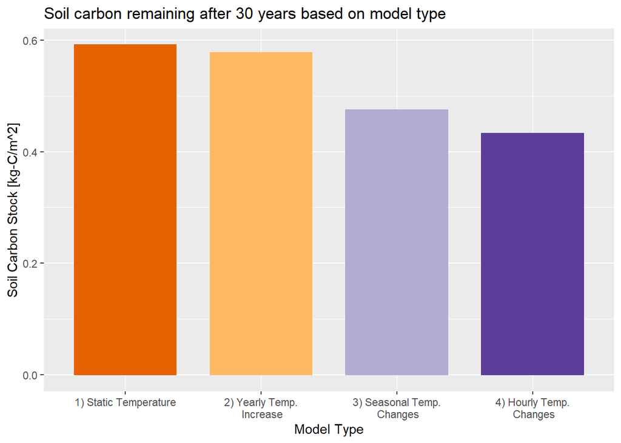

## Discussion

2: There are equal numbers of daylight and nighttime hours.

Neither of these are true simultaneously, but further research could create a temperature model to reflect these for a given location.